# Medidas de tendencia central

[Delgado Gómez Saúl Eduardo](https://isauldelgado.github.io)

Estadística 2022-2, [Facultad de economía](http://www.economia.unam.mx/)

2/3/2022

### 1. ¿Qué son las medidas de tendencia central? 🤔

> Definición: “La medida de tendencia central (moda,media y mediana), parámetro de tendencia central o medida de centralización es un número ubicado hacia el centro de la distribución de los valores de una serie de observaciones (medidas), en la que se encuentra ubicado el conjunto de los datos. Las medidas de tendencia central más utilizadas son: media, mediana u moda. Cuando se hace referencia únicamente a la posición de estos parámetros dentro de la distribución, independientemente de que esté más o menos centrada, se habla de estas medidas como medidas de posición.1 En este caso se incluyen también los cuantiles entre estas medidas.”

[Wikipedia (2022)](https://es.wikipedia.org/wiki/Medidas_de_tendencia_central)

Para este ejemplo, primero generaremos una serie de **100** números aleatorios entre **1** y **20** mediante la función `sample`. El argumento `TRUE` nos permitirá generar una muestra con remplazo:

```r
numeros <- sample(1:20, 100, TRUE)
numeros
```

```
##   [1] 16  6 16  3 17 15  6 16  2  6 17  9 11  1  6  6  5 17 15  4  5  1 14  5 19
##  [26] 19 18  9 16 18 14 12  7 13 15  5 12  9 16 19 16 11 10 20 18 15 16  6  3 12
##  [51] 12  7 10  7 17 20  5  8  1  7  1  1  5  6  3  3  4 14 19  9  5 12  3  8 16
##  [76] 19  2  1  9  5 15  4 18  5 17 12  6  8  1  1 17 17 19 15  7 20  2 12  7 16
```

### 2. Mediana 📍

> Definición: “La **mediana** es el valor que ocupa el lugar central de todos los datos cuando éstos están ordenados de menor a mayor.”

[Superprof (2022)](https://www.superprof.es/apuntes/escolar/matematicas/estadistica/descriptiva/mediana.html)

Para obtener la **mediana**, podemos ordenar los `numeros` de menor a mayor, **el número que esté en medio de la muestra será la mediana**. Si utilizamos R, se puede hacer el cálculo de la **mediana** con la función `median`:

```r
mediana <- median(numeros)
mediana
```

```
## [1] 9.5
```

### 3. Media 🧮

> Definición: “La media, a diferencia de la esperanza matemática, es un término matemático. Por su parte, la [**esperanza matemática**](https://economipedia.com/definiciones/esperanza-matematica.html)es un término estadístico, relacionado con las probabilidades. El cálculo de ambas variables viene, muchas veces, a ser el mismo. No obstante, no siempre se utilizan en el mismo contexto.”

[Economipedia (2022)](https://economipedia.com/definiciones/media.html)

$$Media ={\frac {1}{n}}\sum _{i=1}^{n}a_{i}={\frac {a_{1}+a_{2}+\cdots +a_{n}}{n}}$$

Si usamos R, podemos obtener la media de una muestra si utlilizamos la función **mean**:

```r
media <- mean(numeros)
media
```

```
## [1] 10.25
```

### 4. Moda 📊

> Definición: “La **moda** es el valor más repetido dentro de un conjunto de números. La forma más fácil de identificar este valor consiste simplemente en ordenar todos los números y a continuación contar cuántas veces aparece cada número.”

[Calcuvio (2022)](https://www.calcuvio.com/moda-media-mediana)

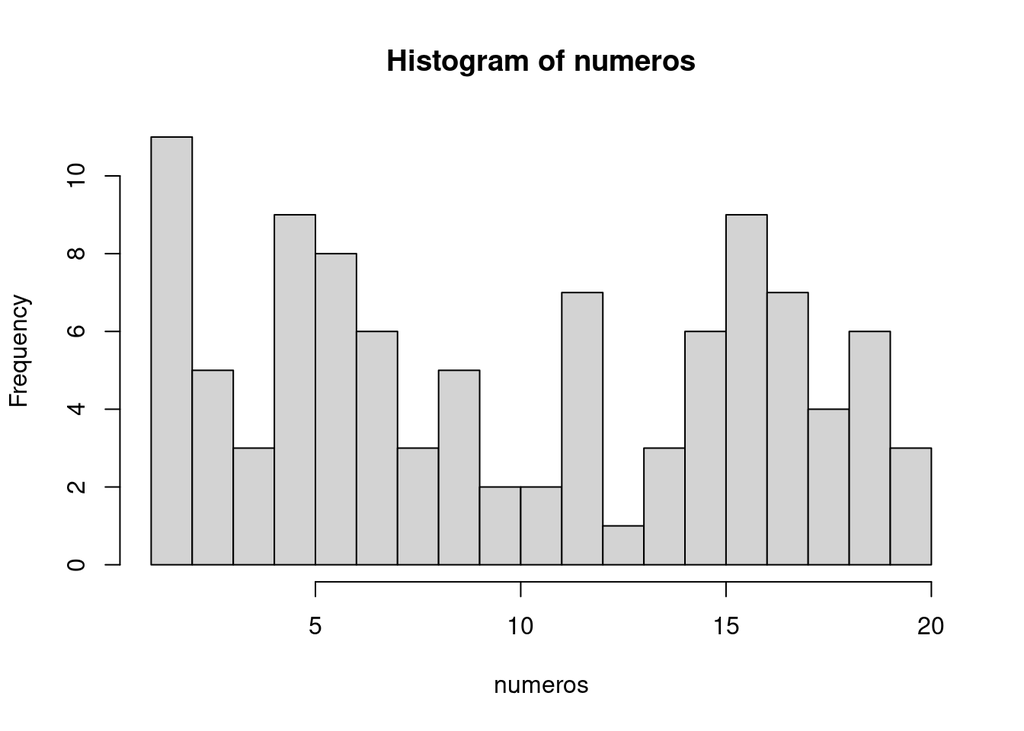

```r
# El argumento breaks nos permite dividir en histograma en las partes que queramos
hist(numeros, breaks = 20)
```

Para obtener un resultado con más precisión, podemos obtener la **moda** si generamos una **tabla de frecuencias** con la función `table` y la función `data.frame`, **aquel elemento con mayor frecuencia será la moda**:

```r
tabla.frecuencias <- data.frame(table(numeros))
tabla.frecuencias
```

```
##    numeros Freq
## 1        1    8
## 2        2    3
## 3        3    5
## 4        4    3
## 5        5    9
## 6        6    8
## 7        7    6
## 8        8    3
## 9        9    5
## 10      10    2
## 11      11    2
## 12      12    7
## 13      13    1
## 14      14    3
## 15      15    6
## 16      16    9
## 17      17    7
## 18      18    4
## 19      19    6
## 20      20    3
```

### 5. Ejercicio 👩‍💻👨‍💻✍

Aplica lo que aprendiste, obten la **mediana**, **media** y **moda** de la siguiente muestra de números:

```r
# Con la función seq, creamos una secuencia de 1 a 10 en intervalos de 0.1 en 0.1
secuencia <- seq(1, 10, 0.1)
muestra <- sample(secuencia, 100, TRUE)
muestra
```

```
##   [1]  2.6  7.4  9.3  4.0  3.6  1.9  1.9  1.2  3.5  8.8  6.9  5.2  1.9  2.2  9.4
##  [16]  7.2  5.7  9.0  5.2  8.6  7.2  1.8  5.4  9.8  7.2  9.7  7.5  1.1  2.1  7.8
##  [31]  7.9  3.6  1.4  5.2  2.9  1.4  6.6  9.2  3.6  5.3  3.4  7.5  1.2  4.8  7.9
##  [46]  5.1  2.8 10.0  8.6  9.2  1.7  8.5  4.4  6.4  2.2  1.7  9.7  4.7  9.2  4.7
##  [61]  1.7  2.0  8.1  7.5  3.9  9.6  9.8  9.4  6.9  7.1  9.4  2.1  1.0  5.4  3.0
##  [76]  1.2  8.3  8.3  6.9  5.3  2.8  3.7  4.3  5.8  4.0  1.0  5.9  4.7  7.2  2.5
##  [91]  9.2  9.9 10.0  4.9  7.8  2.2  5.9  6.4  7.5  6.5
```

##### Mediana

```r
# Aquí el cálculo de la mediana
```

##### Media

```r
# Aquí el cálculo de la media
```

##### Moda

```r
# Aquí el cálculo de la moda
```

💻[Código disponible en RStudio Cloud](https://rstudio.cloud/project/3671022)💻